# Group project

Jakub Grad

2024-11-27

```r
train <- read.csv(file = "kaggle/train.csv")
test <- read.csv(file = "kaggle/test.csv")

# Select only numeric columns from 'train'
train_numeric <- train[, sapply(train, is.numeric)]
test_numeric <- test[, sapply(test, is.numeric)]

linear_regressor <- glm(formula = log_pSat_Pa ~ ., data=train)
test$TARGET <- predict(linear_regressor, newdata=test)

submission_df <- test[, c("ID", "TARGET")]
write.csv(submission_df, "kaggle_submission.csv", row.names = FALSE)
```

[figure not shown]

```r
pairs(train[, sapply(train, is.numeric)])
```

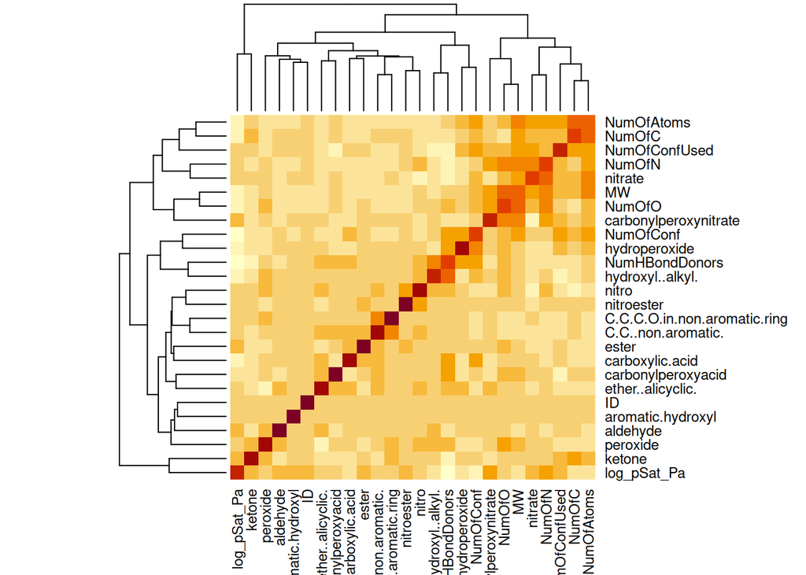

```r
# Compute the correlation matrix
cor_matrix <- cor(train_numeric)

# Create a heatmap of the correlation matrix
heatmap(cor_matrix)
```

Ideas: Use cross validation before submitting?

Perform Lasso?

```r
library(glmnet)
any(is.na(train))
```

```
## [1] FALSE
```

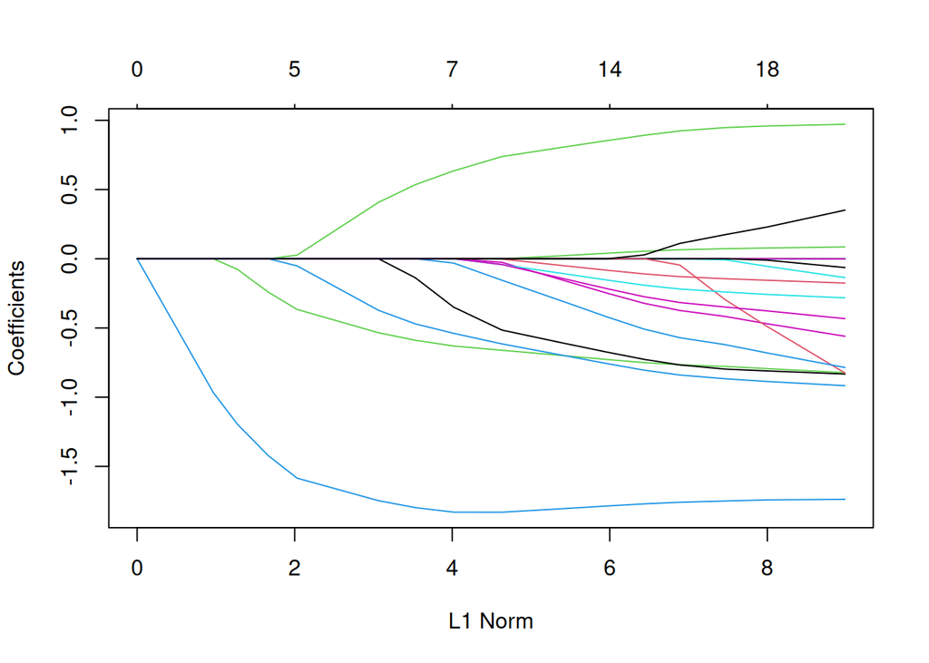

```r
x <- model.matrix(log_pSat_Pa ~ ., train_numeric)[,-1]
y <- train_numeric$log_pSat_Pa

grid <- 10^ seq (10,-2, length = 100)

lasso.mod <- glmnet(x, y, alpha = 1, lambda = grid)
plot(lasso.mod)
```

Let’s find out the CV error

```r
library(glmnet)
set.seed (17)
cv.error.100 <- rep(0, 100)

cv.lasso <- cv.glmnet(x, y, alpha = 1, lambda = grid, nfolds = 10)

best.lambda <- cv.lasso$lambda.min
best.lambda
```

```
## [1] 0.01
```

```r
best.coefficients <- coef(cv.lasso, s = best.lambda)
```

I’ve created a model using best coefficients from lasso and it has a lower score than without using lasso. The best lambda returned is the lowest one, implying that lasso is not the right approach.

```r
test$TARGET <- predict(cv.lasso, newx = model.matrix(~ ., test_numeric)[,-1], s = best.lambda)

submission_df <- test[, c("ID", "TARGET")]
write.csv(submission_df, "lasso.csv", row.names = FALSE)
```

What about ridge regression?

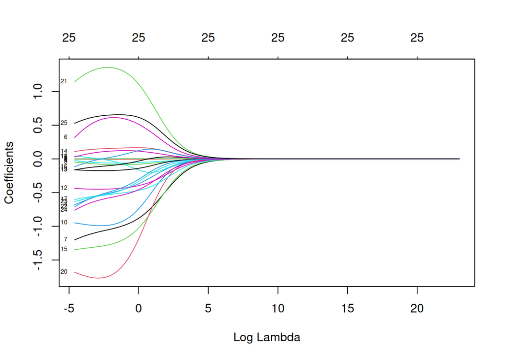

```r
ridge.mod <- glmnet(x, y, alpha = 0, lambda = grid)

plot(ridge.mod, xvar = "lambda", label = TRUE)
```

Cross-Validation for Ridge

```r
set.seed(17)

# Perform cross-validation
cv.ridge <- cv.glmnet(x, y, alpha = 0, lambda = grid, nfolds = 10)

# Optimal lambda
best.lambda <- cv.ridge$lambda.min
cat("Best lambda:", best.lambda, "\n")
```

```
## Best lambda: 0.01
```

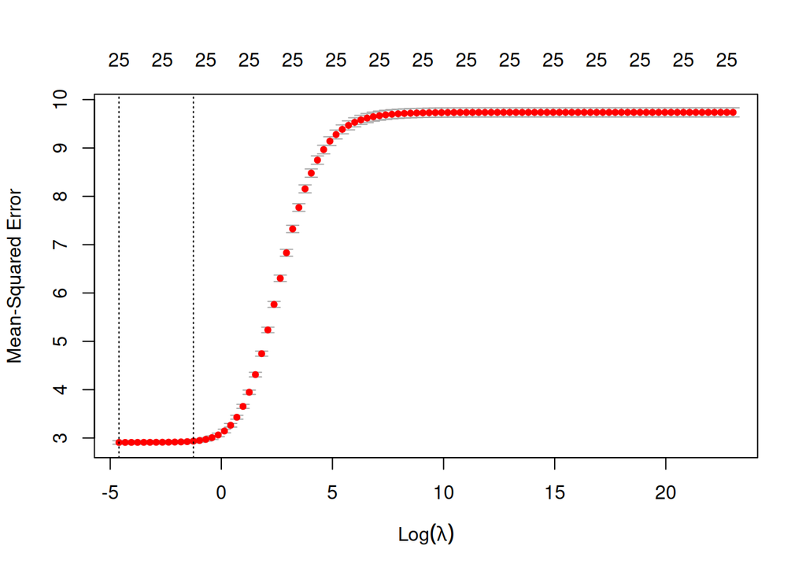

```r
# Plot cross-validation curve
plot(cv.ridge)
```

Predict on test data, create a submission. Result is 0.7101 which is still worse than regular regression.

```r
test$TARGET <- predict(cv.ridge, newx = model.matrix(~ ., test_numeric)[,-1], s = best.lambda)

submission_df <- test[, c("ID", "TARGET")]
write.csv(submission_df, "ridge_submission.csv", row.names = FALSE)
```

Plot plots to show correlation

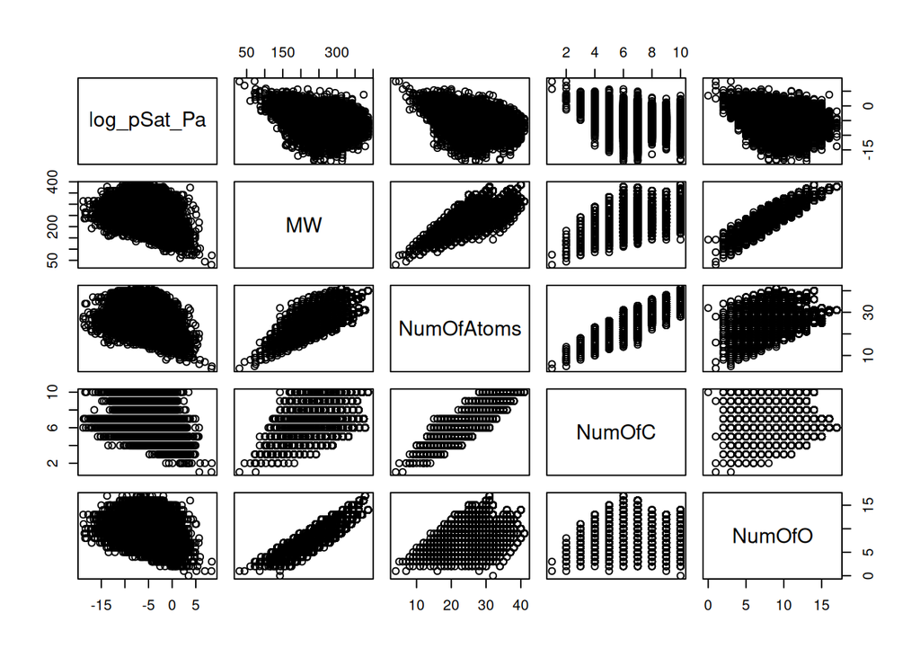

```r
library(ggplot2)

# Subset 1: Select a few numeric predictors
subset_1 <- train_numeric[, c("log_pSat_Pa", "MW", "NumOfAtoms", "NumOfC", "NumOfO")]
# Create pairwise plots for subset_1
pairs(subset_1)
```

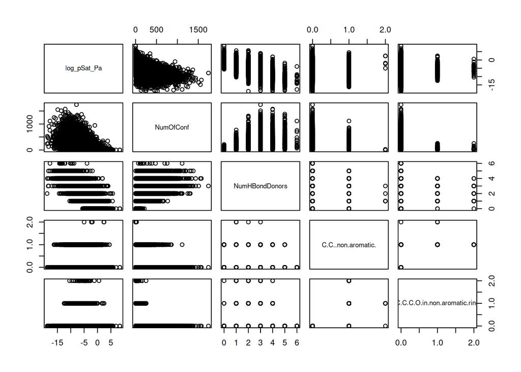

```r
# Subset 2: Select another few predictors, focusing on other numeric and categorical features
subset_2 <- train_numeric[, c("log_pSat_Pa", "NumOfConf", "NumHBondDonors", "C.C..non.aromatic.", "C.C.C.O.in.non.aromatic.ring")]
# Create pairwise plots for subset_2
pairs(subset_2)
```

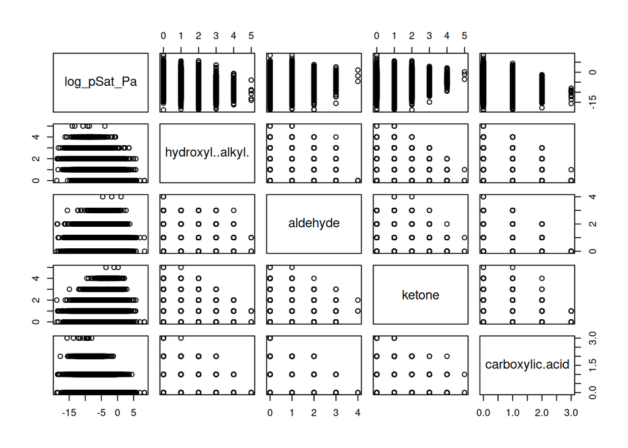

```r
# Subset 3: A set focusing on some chemical features that may affect log_pSat_Pa
subset_3 <- train_numeric[, c("log_pSat_Pa", "hydroxyl..alkyl.", "aldehyde", "ketone", "carboxylic.acid")]
# Create pairwise plots for subset_3
pairs(subset_3)
```

The plots shows that the correlation, if present, is terribly unlinear. It also seems that there’s lots and lots of responses for a single input for most of the graphs.

GAMs. Dont work because all variables need to have at least 4 distinct values, and this dataset sometimes has 3.

```r
# library(gam)
# library(glmnet)
#
# # Fit a GAM model (log_pSat_Pa ~ s(*) for smooth terms)
# gam_model <- gam(log_pSat_Pa ~ s(MW, 4) + s(NumOfAtoms, 4) + s(NumOfC, 4) + s(NumOfO, 4) + s(NumOfN, 4) + ...
```

Let’s try regression trees is not doing very well by default (0.5852)

```r
library(rpart)

# Fit a regression tree model
regression_tree <- rpart(log_pSat_Pa ~ ., data = train_numeric, method = "anova")

# View the model summary
summary(regression_tree)
```

```
## Call:
## rpart(formula = log_pSat_Pa ~ ., data = train_numeric, method = "anova")
##   n= 26637
##
##           CP nsplit rel error    xerror        xstd
## 1 0.32245620      0 1.0000000 1.0001990 0.009169051
## 2 0.08932536      1 0.6775438 0.6776880 0.006466496
## 3 0.04242160      2 0.5882184 0.5883886 0.005863026
## 4 0.03770925      3 0.5457968 0.5460740 0.005409666
## 5 0.03731730      4 0.5080876 0.5165167 0.005324072
## 6 0.01634388      5 0.4707703 0.4710810 0.005075819
## 7 0.01227926      6 0.4544264 0.4547683 0.004991461
## 8 0.01185946      7 0.4421471 0.4421463 0.004918272
## 9 0.01000000      8 0.4302877 0.4310733 0.004834669
##
## Variable importance
##   NumHBondDonors hydroxyl..alkyl.           NumOfC        NumOfConf
##               46               13               11                8
##       NumOfAtoms    hydroperoxide    NumOfConfUsed           NumOfN
##                8                4                3                2
##               MW          nitrate           ketone
##                2                1                1
##
## Node number 1: 26637 observations,    complexity param=0.3224562
##   mean=-5.516747, MSE=9.735229
##   left son=2 (9789 obs) right son=3 (16848 obs)
##   Primary splits:
##       NumHBondDonors  < 2.5      to the right, improve=0.32245620, (0 missing)
##       NumOfConf       < 206.5    to the right, improve=0.19847570, (0 missing)
##       carboxylic.acid < 0.5      to the right, improve=0.08399772, (0 missing)
##       NumOfAtoms      < 20.5     to the right, improve=0.08357227, (0 missing)
##       hydroperoxide   < 0.5      to the right, improve=0.06988999, (0 missing)
##   Surrogate splits:
##       hydroxyl..alkyl. < 1.5      to the right, agree=0.765, adj=0.362, (0 split)
##       NumOfConf        < 364.5    to the right, agree=0.681, adj=0.132, (0 split)
##       hydroperoxide    < 1.5      to the right, agree=0.670, adj=0.102, (0 split)
##       NumOfConfUsed    < 8.5      to the left,  agree=0.667, adj=0.094, (0 split)
##       NumOfN           < 0.5      to the left,  agree=0.655, adj=0.062, (0 split)
##
## Node number 2: 9789 observations,    complexity param=0.0424216
```

[output cut: 119 more lines]

```
##       NumOfAtoms < 18.5     to the right, agree=0.860, adj=0.300, (0 split)
##       MW         < 152.0453 to the right, agree=0.826, adj=0.131, (0 split)
##       NumOfO     < 1.5      to the right, agree=0.801, adj=0.002, (0 split)
##
## Node number 24: 1811 observations
##   mean=-7.028348, MSE=3.441906
##
## Node number 25: 4121 observations
##   mean=-5.464883, MSE=3.214258
##
## Node number 30: 3601 observations
##   mean=-2.299646, MSE=3.075235
##
## Node number 31: 899 observations
##   mean=-0.1957874, MSE=3.770156
```

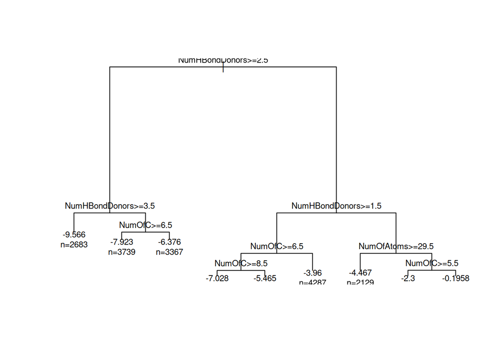

```r
# Visualize the tree (optional, but useful for understanding the splits)
plot(regression_tree)
text(regression_tree, use.n = TRUE, cex = 0.7)
```

```r
# Make predictions on the test data
test$TARGET <- predict(regression_tree, newdata = test_numeric)

# Create the submission dataframe
submission_df <- test[, c("ID", "TARGET")]

# Write the submission to a CSV file
write.csv(submission_df, "regression_tree_submission.csv", row.names = FALSE)
```

Let’s try a bigger regression tree:

```r
library(tree)

# Fit the regression tree with a bigger tree by passing control
regression_tree_big <- tree(log_pSat_Pa ~ ., data = train_numeric, control = tree.control(nobs = nrow(train_numeric), mindev = 0.0005))

# View the model summary
summary(regression_tree_big)
```

```
##
## Regression tree:
## tree(formula = log_pSat_Pa ~ ., data = train_numeric, control = tree.control(nobs = nrow(train_numeric),
##     mindev = 5e-04))
## Variables actually used in tree construction:
##  [1] "NumHBondDonors"        "NumOfAtoms"            "NumOfC"
##  [4] "NumOfConf"             "carboxylic.acid"       "MW"
##  [7] "NumOfO"                "hydroxyl..alkyl."      "carbonylperoxynitrate"
## [10] "ketone"                "C.C..non.aromatic."    "NumOfConfUsed"
## Number of terminal nodes:  65
## Residual mean deviance:  3.151 = 83740 / 26570
## Distribution of residuals:
##    Min. 1st Qu.  Median    Mean 3rd Qu.    Max.
## -14.340  -1.087  -0.041   0.000   1.033  12.380
```

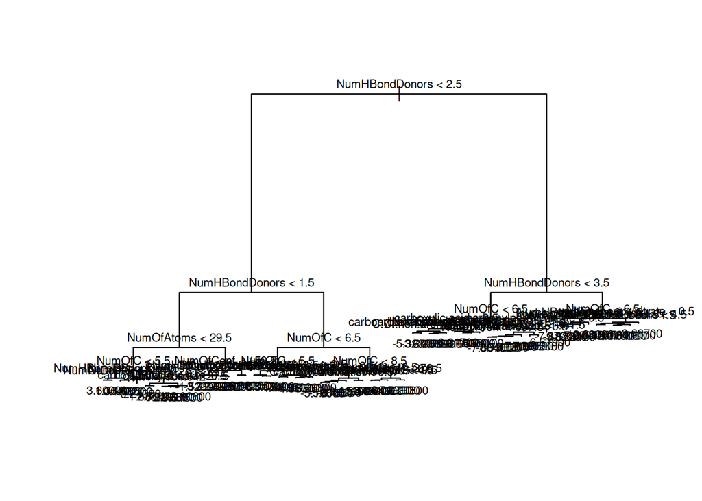

```r
# Visualize the tree (optional)
plot(regression_tree_big)
text(regression_tree_big, use.n = TRUE, cex = 0.7)
```

```r
# Make predictions on the test data
test$TARGET <- predict(regression_tree_big, newdata = test_numeric)

# Create the submission dataframe
submission_df <- test[, c("ID", "TARGET")]

# Write the submission to a CSV file
write.csv(submission_df, "regression_tree_big_submission.csv", row.names = FALSE)
```

Prune the big tree into the best tree according to CV:

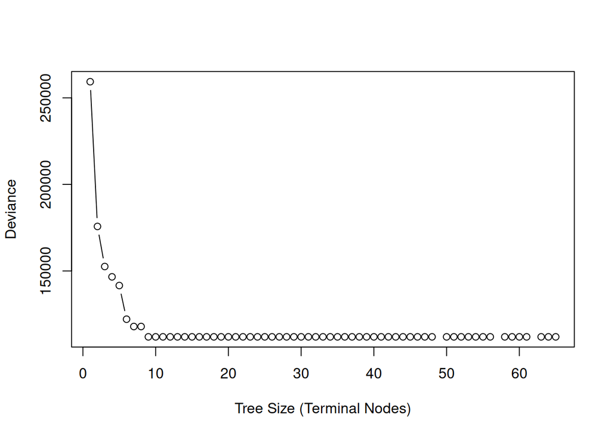

```r
# Perform cross-validation to find the best pruned tree size
cv.tree_result <- cv.tree(regression_tree_big)

# Plot the cross-validation results to inspect the best tree size
plot(cv.tree_result$size, cv.tree_result$dev, type = "b", xlab = "Tree Size (Terminal Nodes)", ylab = "Deviance")
```

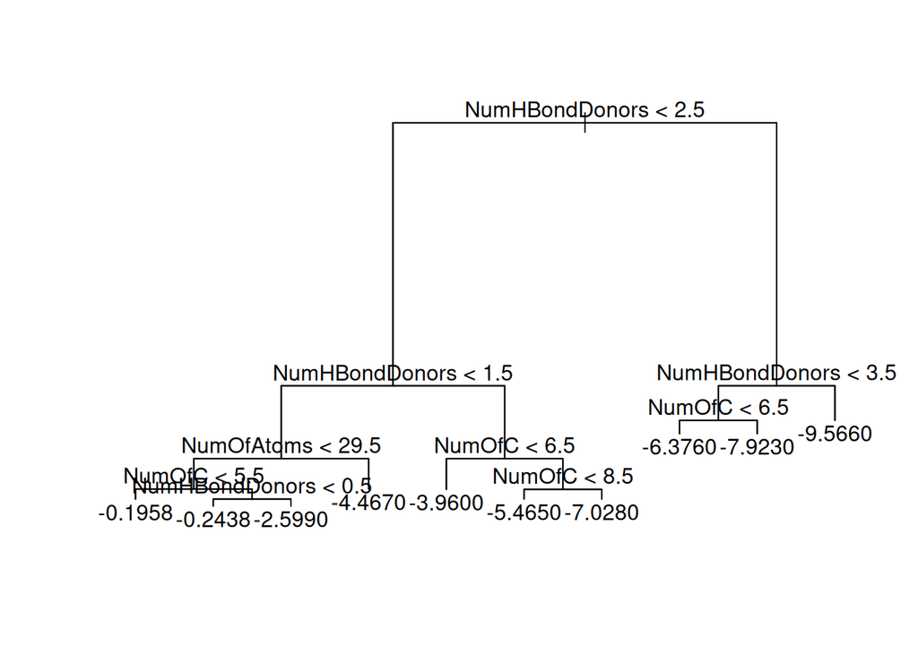

```r
# Find the optimal size (best pruning)
best_size <- cv.tree_result$size[which.min(cv.tree_result$dev)]
best_size <- 10
best_pruned_tree <- prune.tree(regression_tree_big, best = best_size)

# Visualize the best pruned tree
plot(best_pruned_tree)
text(best_pruned_tree, pretty = 0)
```

```r
# Make predictions on the test data
test$TARGET <- predict(best_pruned_tree, newdata = test_numeric)

# Create the submission dataframe
submission_df <- test[, c("ID", "TARGET")]

# Write the submission to a CSV file
write.csv(submission_df, "tree_with_10_nodes_submission.csv", row.names = FALSE)
```

```r
library(randomForest)
# Fit a Random Forest model
set.seed(42)  # Set a seed for reproducibility
rf_model <- randomForest(log_pSat_Pa ~ ., data = train_numeric, ntree = 50, importance = TRUE)

# Print the model summary
print(rf_model)
```

```
##
## Call:
##  randomForest(formula = log_pSat_Pa ~ ., data = train_numeric,      ntree = 50, importance = TRUE)
##                Type of random forest: regression
##                      Number of trees: 50
## No. of variables tried at each split: 8
##
##           Mean of squared residuals: 2.766785
##                     % Var explained: 71.58
```

```r
# View variable importance (optional)
importance(rf_model)
```

```
##                                 %IncMSE IncNodePurity
## ID                            0.2517655   11142.78753
## MW                           18.2056760   10608.10661
## NumOfAtoms                   12.1112117   14455.80666
## NumOfC                       28.8916695   18967.39649
## NumOfO                       18.2281934    5065.52968
## NumOfN                        5.1461714    2932.46036
## NumHBondDonors               40.3044501   80905.98248
## NumOfConf                    21.0451961   45395.63377
## NumOfConfUsed                13.4303742   12205.61887
## C.C..non.aromatic.           19.5315700    2322.43934
## C.C.C.O.in.non.aromatic.ring  4.3323675     202.66830
## hydroxyl..alkyl.              9.1010722    7864.95079
## aldehyde                     13.6795430    2741.47417
## ketone                       18.1381006    3898.08696
## carboxylic.acid              18.7820850    8955.22891
## ester                        11.2211117    1613.71469
## ether..alicyclic.            14.5178209    1301.14469
## nitrate                       7.7355903    1843.08896
## nitro                         4.8518167    1025.98382
## aromatic.hydroxyl             1.1238123      41.47326
## carbonylperoxynitrate        21.9673927    6740.62906
## peroxide                     21.2328330    1832.13034
## hydroperoxide                 7.9466109    4819.02286
## carbonylperoxyacid           13.9347618    2623.13458
## nitroester                    2.3412451     175.77567
```

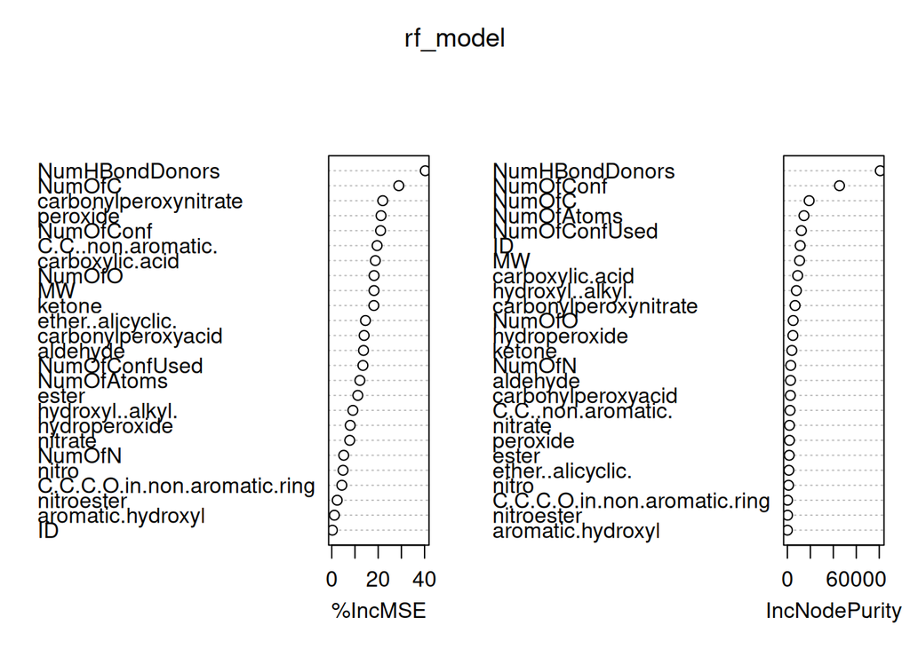

```r
varImpPlot(rf_model)
```

```r
# Make predictions on the test data
test$TARGET <- predict(rf_model, newdata = test_numeric)

# Create the submission dataframe
submission_df <- test[, c("ID", "TARGET")]

# Write the submission to a CSV file
write.csv(submission_df, "random_forest_submission.csv", row.names = FALSE)
```